| title: “Brownlows Bets” |
| --- |
| author: “Moises Sales” |
| date: “10/16/2019” |
| output: html_document: default |

# Introduction

At the first day of class there are 35 students in Math Statistics class and professor Brownlow always proposes this bet to his students “I will wager $2 to your bet of $1 that at least two people in today’s class have the same birthday. He tells me he has made that bet 1137 times so far. Where do you think his profits are? Discuss this in a markdown document

# Methods

To estimate professor Brownlow’s earnings or losses after 1137 bets, the data sample gathered from the bets will be compiled by first setting a new object for birthdays (BDAYS) which will contain each possible day of the year from an interval 1:365. Then using our (BDAYS) object we will compare the sample tests of each bet results to whether or not they obtained a unique sample number < 35 which is the total number of birthdays per bet. After all 1,137 bets there will be a total amount of money for the bets either in positive or negative money total due to earnings or loses. This data will be shown as a 95% confidence interval over a histogram

# Profit Estimate

```r
Bdays = 1:365
Bsamples = vector("numeric")
TotalDollars = 0
saveDollars = vector("numeric")
```

run the simulation 1137 times.

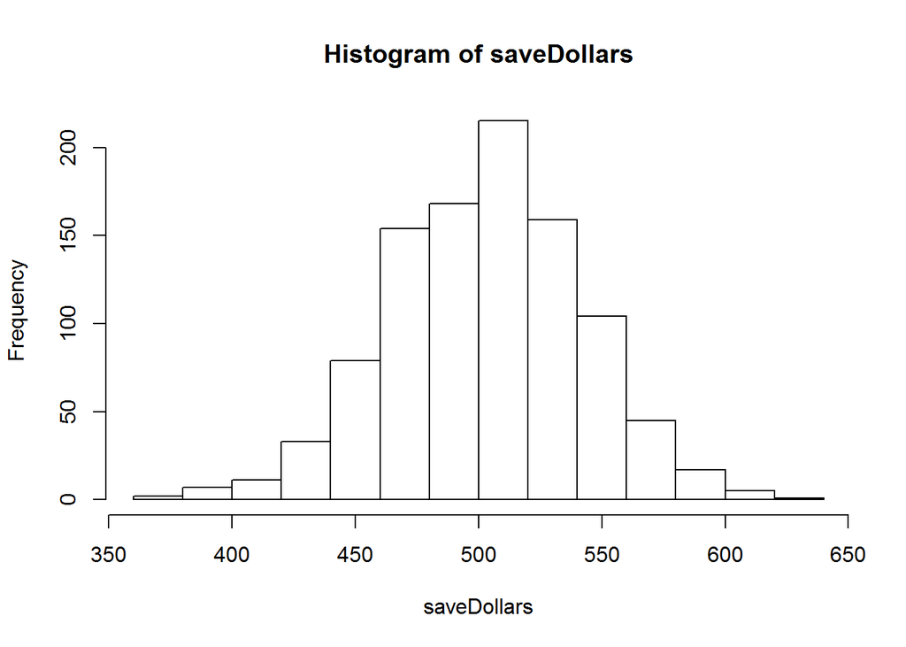

```r
for (loop in 1:1000) {

TotalDollars = 0
classsize = 35
for(i in 1:1137) {
Bsamples = sample(Bdays,35, replace=TRUE)
if (length(unique(Bsamples)) == 35) {
   TotalDollars = TotalDollars -2
} else{
  TotalDollars = TotalDollars +1
}
}

saveDollars[loop] = TotalDollars
}

hist(saveDollars)
```

```r
var(saveDollars)
```

```
## [1] 1556.213
```

```r
print(paste("average return =",mean(saveDollars)))
```

```
## [1] "average return = 503.541"
```

Using resampling, I found the average amount of dollars made per test was around $502.

# Confidence interval of Brownlows earning

```r
varSorted = sort(saveDollars)
LCL = varSorted[25]
UCL = varSorted[975]
print(paste("UCL = ",UCL,"LCL = ",LCL))
```

```
## [1] "UCL =  579 LCL =  423"
```

```r
stdevDollars = sd(saveDollars)
meandDollars = mean(saveDollars)
CI = c(meandDollars-2*stdevDollars, meandDollars+2*stdevDollars)

print(CI)
```

```
## [1] 424.6433 582.4387
```

# Discussion and Conclusion

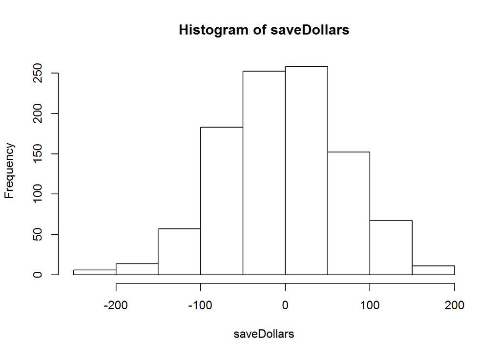

```r
for (loop in 1:1000) {

TotalDollars = 0
classsize = 35
for(i in 1:1137) {
Bsamples = sample(Bdays,35, replace=TRUE)
if (length(unique(Bsamples)) == 35) {
   TotalDollars = TotalDollars -4.4
} else{
  TotalDollars = TotalDollars +1
}
}

saveDollars[loop] = TotalDollars
}

hist(saveDollars)
```

```r
var(saveDollars)
```

```
## [1] 4917.808
```

```r
print(paste("average return =",mean(saveDollars)))
```

```
## [1] "average return = -2.52420000000011"
```

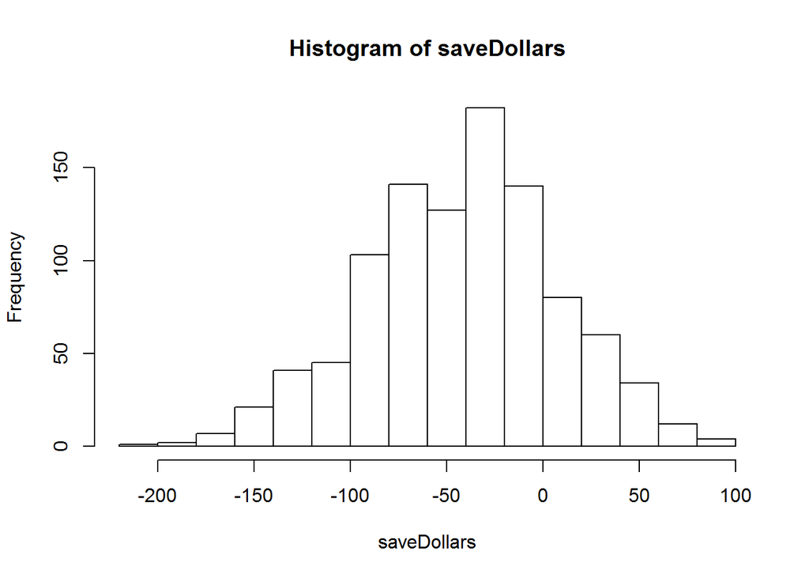

```r
for (loop in 1:1000) {

TotalDollars = 0
classsize = 28
for(i in 1:1137) {
Bsamples = sample(Bdays,28, replace=TRUE)
if (length(unique(Bsamples)) == 28) {
   TotalDollars = TotalDollars -2
} else{
  TotalDollars = TotalDollars +1
}
}

saveDollars[loop] = TotalDollars
}

hist(saveDollars)
```

```r
var(saveDollars)
```

```
## [1] 2500.704
```

```r
print(paste("average return =",mean(saveDollars)))
```

```
## [1] "average return = -41.304"
```